# Financial Time-Series Project

Batchimeg Battur, Ryan Timothy Yu, Harry Yan

4/20/2022

# Project Report 2

## A. Overview of the primary asset and the market for the asset

As our team members were interested in technology field, we have chosen **XLK** ETF as the asset we will be investigating throughout this project.

### Brief introduction

XLK was launched in December of 1998 and was one of the first to launch in its’ field, which specifically narrowly focused on the US technology sector of the S&P 500 Index. Also, it is heavily concentrated on large-cap companies which lets the ETF to result in lower volatility than small cap companies and tilt toward value compared to other tech-industry benchmark index.

XLK has an MSCI ESG Fund Rating of AAA based on a score of 10.00 out of 10. The MSCI ESG Fund Rating measures the resiliency of portfolios to long-term risks and opportunities arising from environmental, social, and governance factors. There are few competing ETFs such as IYW, FTEC, PSCT, but the XLK is known as the long time cheapest and largest in its segment.

XLK was issued by State Street Global Advisors Funds Management Inc. has a gross expense ratio of 0.1% and the total asset under the management as of April 2022 is $46,350.97 M.

The XLK top 10 holdings are shown in figure 1 below:

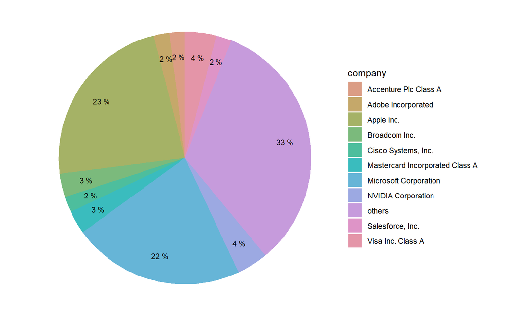

```r
pie
```

*Fig 1. XLK top 10 holdings*

### Secondary Asset

For our secondary asset we will be choosing the Vanguard Information Technology ETF (VGT). This ETF closely relates to XLK as they are both following the technology sector and have similar holdings of technology companies.

## B. One application for the econometric analysis.

A hedge fund manager that is considering incorporating XLK into their client’s portfolio can conduct a Value at Risk analysis to determine the potential for loss and the probability that the defined loss will occur.

## C.1. XLK Properties of time-series: Descriptive Statistics

We pulled the XLK price data from Yahoo finance between December 1998 and April 2022.

```r
getSymbols("XLK",from="1998-12-01",to="2022-04-07")  #specify the data span
```

```
## [1] "XLK"
```

```r
dim(XLK)  #finds the size of the data downloaded
```

```
## [1] 5861    6
```

```r
head(XLK)  #shows the first 6 rows of data
```

```
##            XLK.Open XLK.High  XLK.Low XLK.Close XLK.Volume XLK.Adjusted
## 1998-12-22 32.40625 32.50000 31.78125  32.04688     300500     24.53002
## 1998-12-23 32.75000 32.81250 32.15625  32.81250     338300     25.11606
## 1998-12-24 32.81250 32.81250 32.56250  32.68750     243700     25.02039
## 1998-12-28 33.18750 33.18750 32.59375  32.78125     309300     25.09214
## 1998-12-29 32.93750 33.01562 32.50000  32.87500     123800     25.16390
## 1998-12-30 32.68750 33.14062 32.57812  32.75000      95600     25.06823
```

```r
tail(XLK)   #shows the last 6 rows of data
```

```
##            XLK.Open XLK.High XLK.Low XLK.Close XLK.Volume XLK.Adjusted
## 2022-03-30   162.66   163.12  160.47    161.32    9340100     160.9019
## 2022-03-31   161.30   161.60  158.69    158.93    9712000     158.5181
## 2022-04-01   159.09   159.46  156.69    158.46   14104800     158.0493
## 2022-04-04   158.87   161.55  158.81    161.47   11524100     161.0515
## 2022-04-05   160.77   161.14  157.52    158.07   11794100     157.6603
## 2022-04-06   155.44   155.80  152.96    154.33   17112700     153.9300
```

The basic statistics are shown below:

```r
bstat<- basicStats(XLK)
datatable(bstat)
```

|  | XLK.Open | XLK.High | XLK.Low | XLK.Close | XLK.Volume | XLK.Adjusted |
| --- | --- | --- | --- | --- | --- | --- |
| nobs | 5861 | 5861 | 5861 | 5861 | 5861 | 5861 |
| NAs | 0 | 0 | 0 | 0 | 0 | 0 |
| Minimum | 11.5 | 11.82 | 11.4 | 11.58 | 39400 | 8.863989 |
| Maximum | 176.979996 | 177.039993 | 175.289993 | 176.649994 | 68269500 | 175.867172 |
| 1. Quartile | 21.76 | 21.92 | 21.59 | 21.75 | 1111100 | 17.452412 |
| 3. Quartile | 51 | 51.625 | 50.34375 | 51.0625 | 9678000 | 42.989944 |
| Mean | 43.487754 | 43.837125 | 43.093174 | 43.482783 | 6736944.548712 | 39.153573 |
| Median | 29.75 | 29.98 | 29.51 | 29.719999 | 5817000 | 25.448519 |
| Sum | 254881.726862 | 256929.389977 | 252569.095468 | 254852.589532 | 39485232000 | 229479.089782 |
| SE Mean | 0.441614 | 0.444993 | 0.43782 | 0.441776 | 86001.822887 | 0.452766 |

[output cut: 6 more lines]

We performed Jarque-Bera test to examine the normality of the log-return. We found that the p-value<2.2e-16, which is less than 0.05. Therefore, we concluded that the log-return does not follow the normal distribution.

```r
#Normality test
XLK_Price_Adj=XLK$XLK.Adjusted #% Define a new variable
XLK_R=diff(log(XLK_Price_Adj))
XLK_R = na.omit(XLK_R)
jarque.bera.test(XLK_R)
```

```
##
##  Jarque Bera Test
##
## data:  XLK_R
## X-squared = 12451, df = 2, p-value < 2.2e-16
```

### Secondary Asset (VGT): Properties of time-series: Descriptive Statistics

We pulled the VGT price data from Yahoo finance between December 1998 and April 2022.

```r
getSymbols("VGT",from="1998-12-01",to="2022-04-07")  #specify the data span
```

```
## [1] "VGT"
```

The basic statistics are shown below:

```r
bstat2<- basicStats(VGT)
datatable(bstat2)
```

|  | VGT.Open | VGT.High | VGT.Low | VGT.Close | VGT.Volume | VGT.Adjusted |
| --- | --- | --- | --- | --- | --- | --- |
| nobs | 4579 | 4579 | 4579 | 4579 | 4579 | 4579 |
| NAs | 0 | 0 | 0 | 0 | 0 | 0 |
| Minimum | 29.59 | 30.41 | 28.85 | 29.27 | 0 | 25.585514 |
| Maximum | 466.829987 | 467.059998 | 461.579987 | 466.100006 | 6564500 | 464.473267 |
| 1. Quartile | 52.305 | 52.700001 | 51.789999 | 52.240002 | 94550 | 45.873403 |
| 3. Quartile | 151.325004 | 151.875 | 150.82 | 151.555 | 401000 | 144.042442 |
| Mean | 120.42432 | 121.24665 | 119.46596 | 120.418799 | 317805.437869 | 114.068423 |
| Median | 73.25 | 73.599998 | 72.800003 | 73.290001 | 228300 | 66.093872 |
| Sum | 551422.959797 | 555188.409929 | 547034.630088 | 551397.679485 | 1455231100 | 522319.310159 |
| SE Mean | 1.492084 | 1.504054 | 1.478155 | 1.492259 | 5790.025935 | 1.505327 |

[output cut: 6 more lines]

We performed Jarque-Bera test to examine the normality of the log-return. We found that the p-value<2.2e-16, which is less than 0.05. Therefore, we concluded that the log-return does not follow the normal distribution.

```r
#Normality test
VGT_Price_Adj=VGT$VGT.Adjusted #% Define a new variable
VGT_R=diff(log(VGT_Price_Adj)) #% Calculate log returns
VGT_R<-na.omit(VGT_R)
jarque.bera.test(VGT_R)
```

```
##
##  Jarque Bera Test
##
## data:  VGT_R
## X-squared = 14175, df = 2, p-value < 2.2e-16
```

## C.2. Properties of time-series: Vizulatization

The daily and monthly price and volume charts are shown in figure 2 & 3 below. From the observations we can see that the price is non-stationary.

### XLK Daily Price and volume

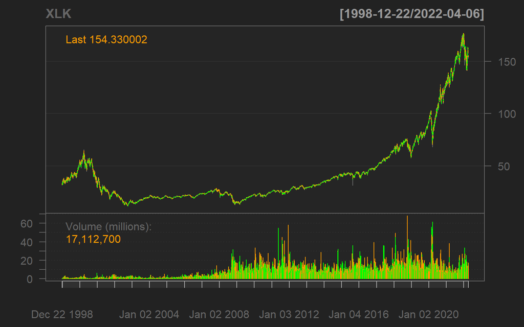

```r
chartSeries(XLK)
```

*Fig 2. XLK Daily price and volume chart*

### XLK Monthly Price and volume

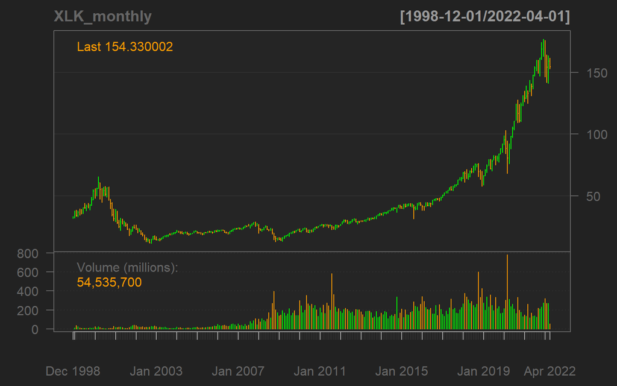

```r
XLK_monthly <- to.monthly(XLK)
chartSeries(XLK_monthly, type="bar")
```

*Fig 3. XLK Monthly price and volume chart*

#### VGT Price and volume

For comparison, the daily price and volume chart for VGT is shown in figure 4 below. From the observations we can see that the price is also non-stationary.

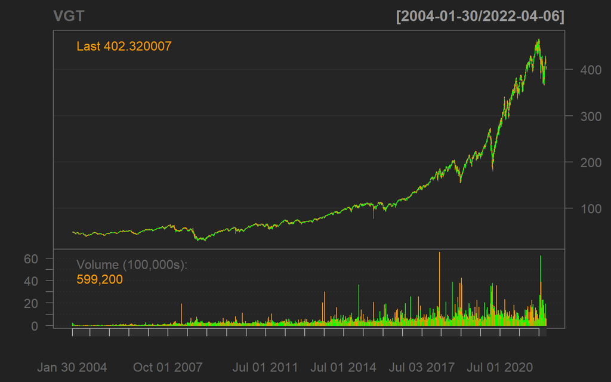

```r
chartSeries(VGT)
```

*Fig 4. VGT Daily price and volume chart*

### Return: XLK chart and test

Next we created a new variable that represents log return of XLK and have plotted it over the time. Refer to figure 5, 6, and 7 below.

#### Relationship Between Daily XLK Returns

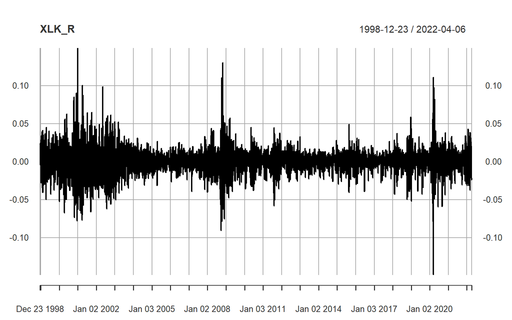

```r
XLK_Price_Adj=XLK$XLK.Adjusted #% Define a new variable
XLK_R=diff(log(XLK_Price_Adj)) #% Calculate log returns
XLK_R<-na.omit(XLK_R)
plot(XLK_R,type='l')
```

*Fig 5. XLK Daily Log return over the time*

#### Relationship Between Weekly XLK Returns

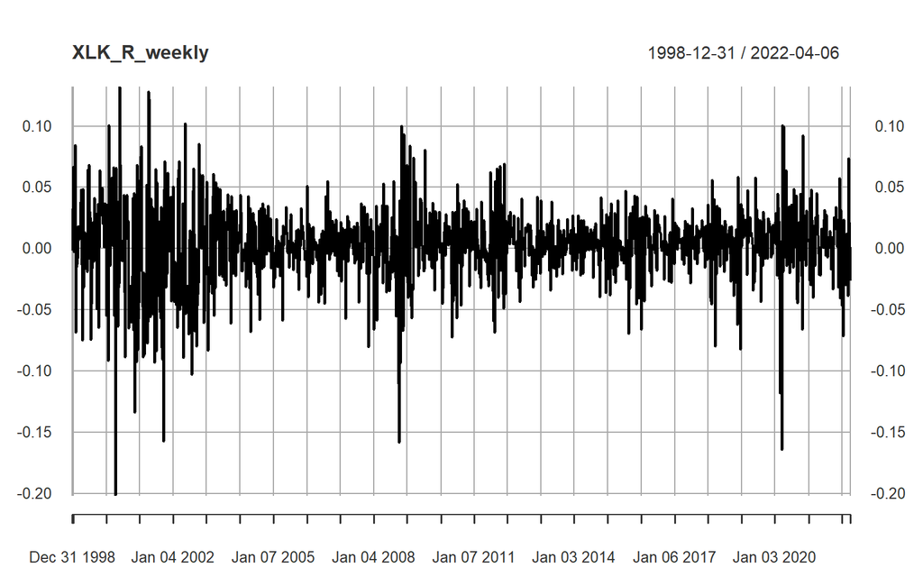

```r
XLK_weekly <- to.weekly(XLK)
XLK_Price_Adj_weekly=XLK_weekly$XLK.Adjusted #% Define a new variable
XLK_R_weekly=diff(log(XLK_Price_Adj_weekly)) #% Calculate log returns
XLK_R_weekly<-na.omit(XLK_R_weekly)
plot(XLK_R_weekly,type='l')
```

*Fig 6. XLK Weekly Log return over the time*

#### Relationship Between Monthly XLK Returns

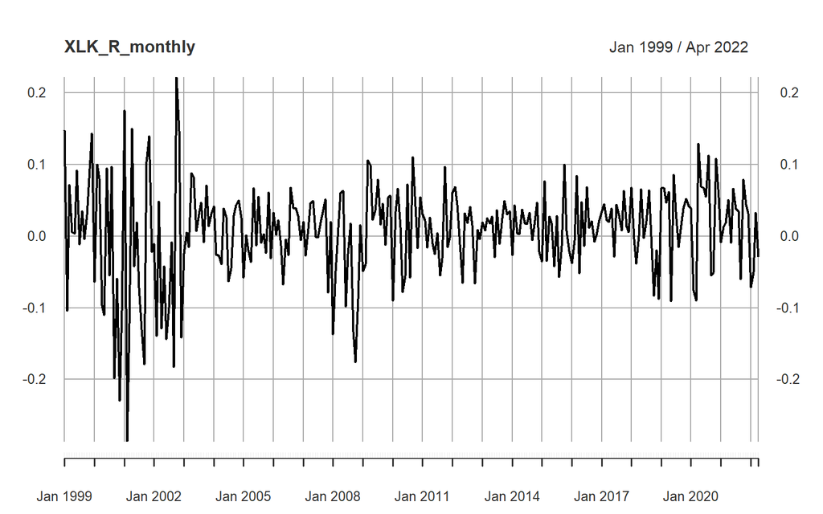

```r
XLK_Price_Adj_monthly=XLK_monthly$XLK.Adjusted #% Define a new variable
XLK_R_monthly=diff(log(XLK_Price_Adj_monthly)) #% Calculate log returns
XLK_R_monthly<-na.omit(XLK_R_monthly)
plot(XLK_R_monthly,type='l')
```

*Fig 7. XLK Monthly Log return over the time*

### Return: VGT chart and test

#### Relationship Between Daily VGT Returns

For comparison, we created a new variable that represents log return of VGT and have plotted it over the time. Refer to figure 8 below.

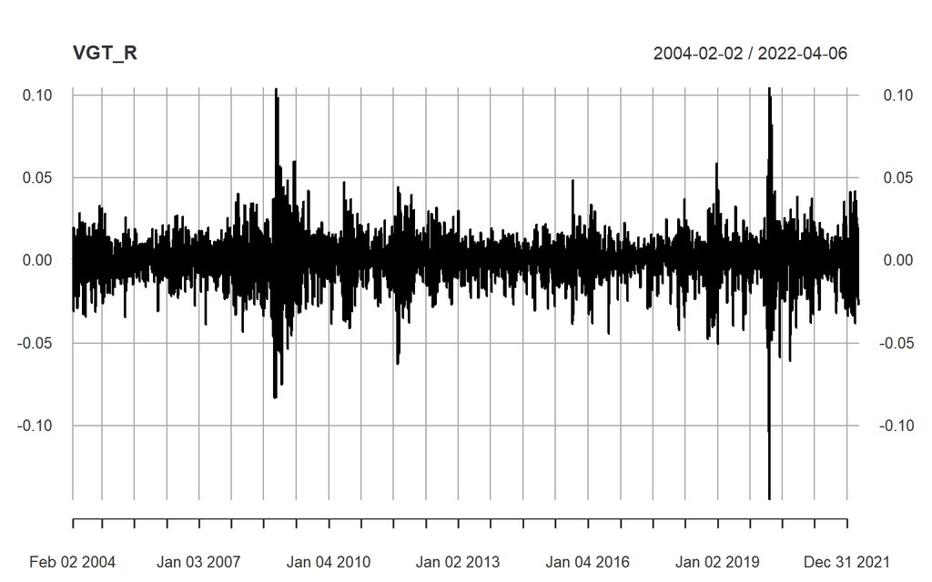

```r
VGT_Price_Adj=VGT$VGT.Adjusted #% Define a new variable
VGT_R=diff(log(VGT_Price_Adj)) #% Calculate log returns
VGT_R<-na.omit(VGT_R)
plot(VGT_R,type='l')
```

*Fig 8. VGT Daily Log return over the time*

## Primary Asset (XLK) vs Secondary Asset (VGT):

We compared the price and volume for both assets over time. We determined that they both follow the same upward trend and are non-stationary. Both assets do not follow a normal distribution based on the Jarque-Bera test and have similar return trends. Since the two have similar statistical properties and follow the same technology sector, this would make the two assets appropriate for multivariate testing in part E.

## C.3 Unit Root and Seasonality Test

### Unit Root

For unit root testing, we conducted the Augmented Dickey-Fuller Test on the log return of XLK, including trend. The resulting p-value of the series without drift and trend is < 2.2e-16. Therefore, we reject the null hypothesis and consider the series to be stationary.

```r
summary(ur.df(XLK_R,type="trend"))
```

```
##
## ###############################################
## # Augmented Dickey-Fuller Test Unit Root Test #
## ###############################################
##
## Test regression trend
##
##
## Call:
## lm(formula = z.diff ~ z.lag.1 + 1 + tt + z.diff.lag)
##
## Residuals:
##       Min        1Q    Median        3Q       Max
## -0.144950 -0.006901  0.000785  0.007598  0.144153
##
## Coefficients:
##               Estimate Std. Error t value Pr(>|t|)
## (Intercept) -4.888e-04  4.264e-04  -1.146   0.2517
## z.lag.1     -1.107e+00  1.913e-02 -57.888   <2e-16 ***
## tt           2.842e-07  1.261e-07   2.254   0.0243 *
## z.diff.lag   3.355e-02  1.307e-02   2.568   0.0103 *
## ---
## Signif. codes:  0 '***' 0.001 '**' 0.01 '*' 0.05 '.' 0.1 ' ' 1
##
## Residual standard error: 0.01631 on 5854 degrees of freedom
## Multiple R-squared:  0.5361, Adjusted R-squared:  0.5359
## F-statistic:  2255 on 3 and 5854 DF,  p-value: < 2.2e-16
##
##
## Value of test-statistic is: -57.888 1117.008 1675.512
##
## Critical values for test statistics:
##       1pct  5pct 10pct
## tau3 -3.96 -3.41 -3.12
## phi2  6.09  4.68  4.03
## phi3  8.27  6.25  5.34
```

### Seasonality

Based on the ACF of the log return of XLK, there is no seasonality in the data because we do not see any reoccurring significant peaks in past lags.

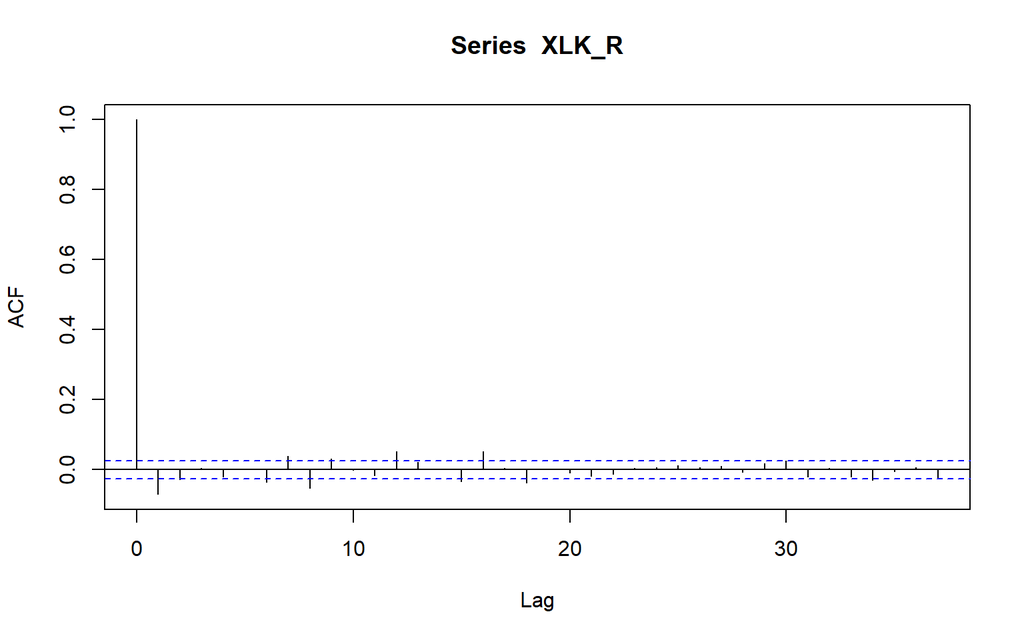

```r
acf(XLK_R)
```

## D. ARIMA model of price and return

We ran the ARIMA model for XLK price, return, and risk.

### ARIMA for XLK Price

```r
auto.arima(XLK[,6])
```

```
## Series: XLK[, 6]
## ARIMA(5,2,0)
##
## Coefficients:
##           ar1      ar2      ar3      ar4      ar5
##       -0.9305  -0.7083  -0.5278  -0.3545  -0.1116
## s.e.   0.0130   0.0172   0.0183   0.0173   0.0130
##
## sigma^2 estimated as 0.7602:  log likelihood=-7508.57
## AIC=15029.13   AICc=15029.15   BIC=15069.19
```

### ARIMA for XLK log return

The ARIMA for XLK log return chose an order of AR(1) with 1 integration. The AIC is -28949.78.

```r
auto.arima(XLK_R)
```

```
## Series: XLK_R
## ARIMA(1,1,0) with drift
##
## Coefficients:
##           ar1  drift
##       -0.5201  0e+00
## s.e.   0.0112  2e-04
##
## sigma^2 estimated as 0.0004181:  log likelihood=14477.89
## AIC=-28949.78   AICc=-28949.77   BIC=-28929.75
```

### ARIMA for XLK Risk (XLK_R^2)

The ARIMA for XLK Risk chose an order of AR(3) and MA(1) with 1 integration. The AIC is -67985.83.

```r
auto.arima(XLK_R^2)
```

```
## Series: XLK_R^2
## ARIMA(3,1,1)
##
## Coefficients:
##          ar1     ar2      ar3      ma1
##       0.0404  0.0845  -0.0620  -0.9018
## s.e.  0.0164  0.0160   0.0152   0.0105
##
## sigma^2 estimated as 5.34e-07:  log likelihood=33997.91
## AIC=-67985.83   AICc=-67985.82   BIC=-67952.45
```

## D.1. Forecasting Power of the ARIMA model

```r
library(forecast)

getSymbols("XLK", from = "1998-04-07", to="2020-04-07")
```

```
## [1] "XLK"
```

```r
XLK_train=data.frame(Date=index(XLK), coredata(XLK)) #% Define a new variable
XLK_R=ts(diff(log(XLK_train$XLK.Adjusted))) #% Calculate log returns
XLK_R<-na.omit(XLK_R)
model = auto.arima(XLK_R)
model
```

```
## Series: XLK_R
## ARIMA(2,0,2) with zero mean
##
## Coefficients:
##           ar1     ar2     ma1      ma2
##       -0.7211  0.0815  0.6517  -0.1692
## s.e.   0.2150  0.2053  0.2129   0.2033
##
## sigma^2 estimated as 0.0002699:  log likelihood=14406.16
## AIC=-28802.31   AICc=-28802.3   BIC=-28769.38
```

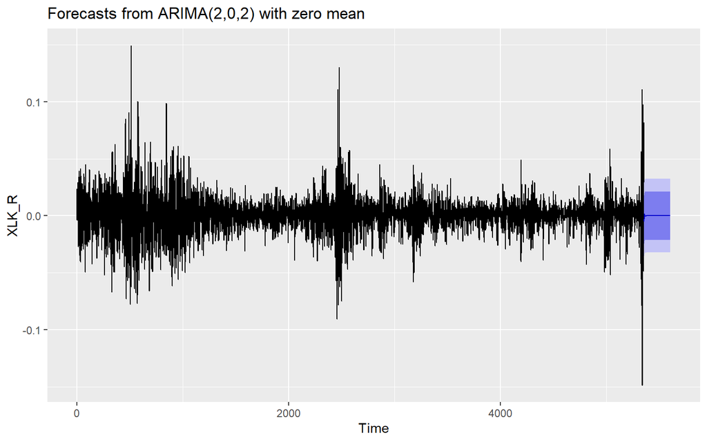

```r
for1 = forecast(model,250)
autoplot(for1)
```

```r
model2 = auto.arima(XLK$XLK.Adjusted)
model2
```

```
## Series: XLK$XLK.Adjusted
## ARIMA(1,2,0)
##
## Coefficients:
##           ar1
##       -0.6111
## s.e.   0.0109
##
## sigma^2 estimated as 0.5119:  log likelihood=-5804.27
## AIC=11612.55   AICc=11612.55   BIC=11625.72
```

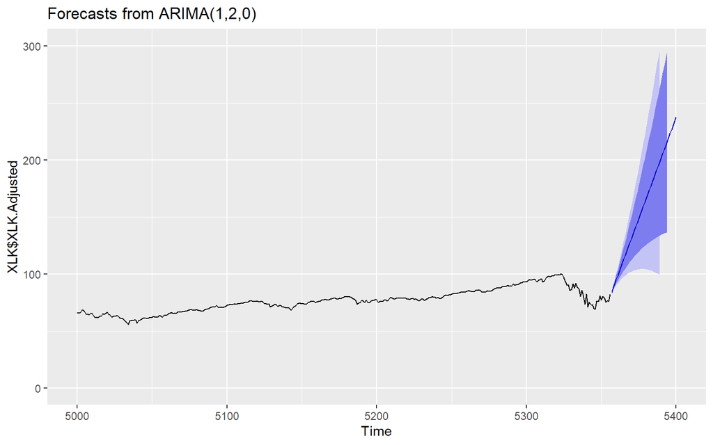

```r
for2 = forecast(model2,250)
autoplot(for2) + ylim(0, 300) + xlim(5000, 5400)
```

```r
getSymbols("XLK", from = "2020-04-08", to="2021-04-07")
```

```
## [1] "XLK"
```

```r
XLK_R=diff(log(XLK$XLK.Adjusted))
mse1 <- mean((na.omit(XLK_R)-for1$mean[-1])^2)
mse2 <- mean((XLK$XLK.Adjusted-for2$mean)^2)
sqrt(mse1)
```

```
## [1] 0.01631404
```

```r
sqrt(mse2)
```

```
## [1] 479.0958
```

## Extra Analysis for XLK_R^2

### ACF for XLK_R^2

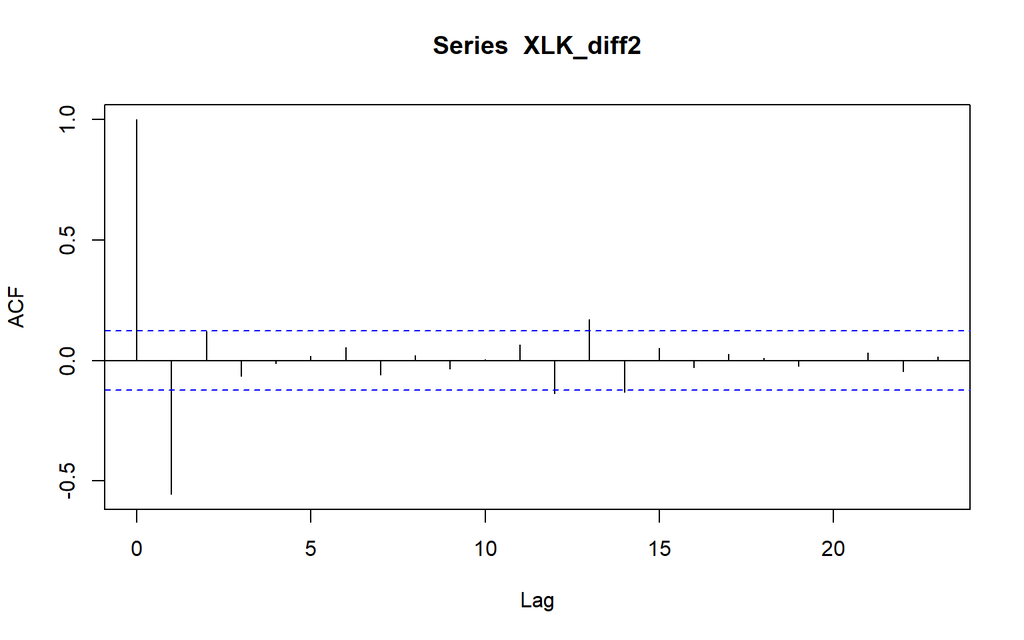

```r
XLK_diff2 <- diff(XLK_R^2)
XLK_diff2 <- na.omit(XLK_diff2)
acf(XLK_diff2)
```

### PACF for XLK_R^2

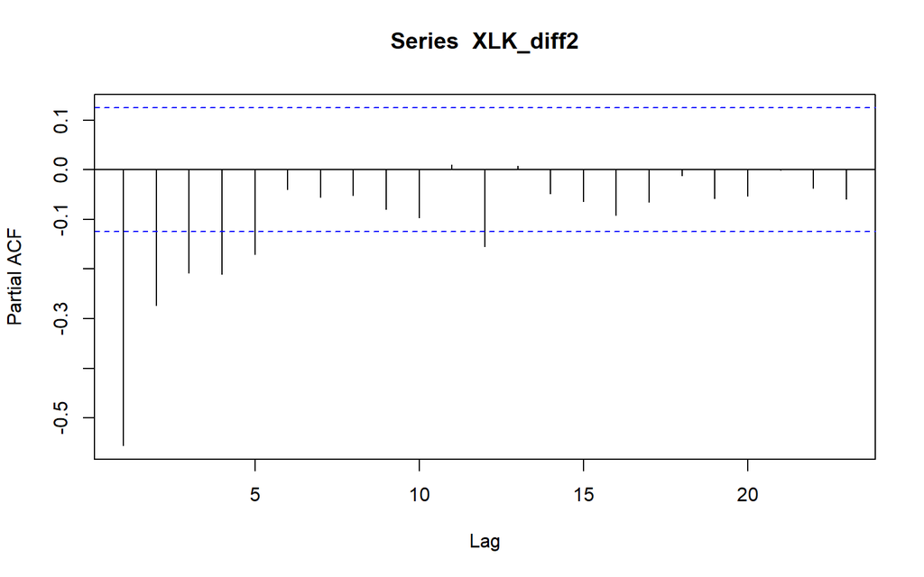

```r
pacf(XLK_diff2)
```

## E. Multi-variate analysis

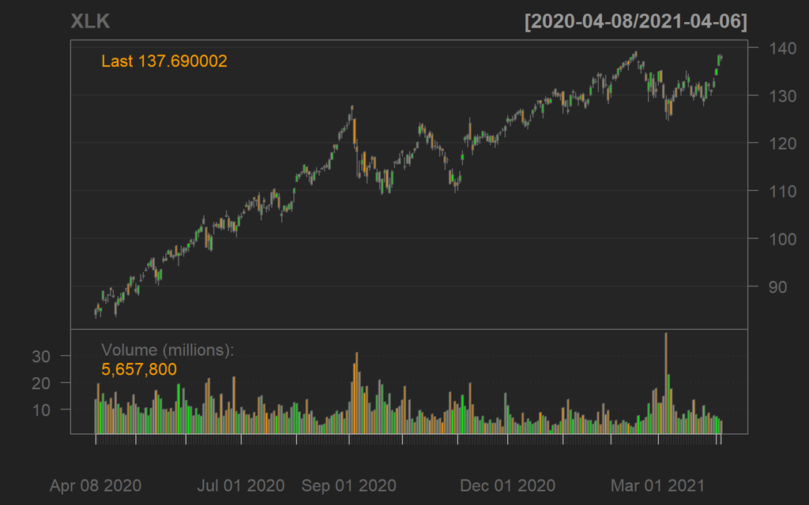

```r
chartSeries(XLK)
```

*Fig 11. XLK Price over the time*

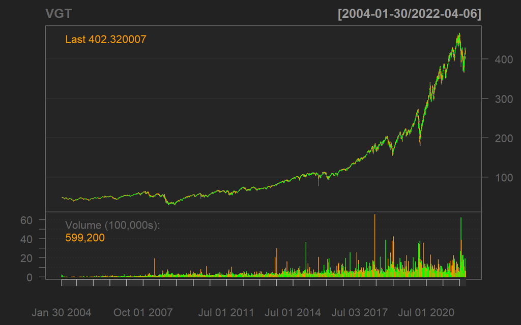

```r
chartSeries(VGT)
```

*Fig 12. VGT Price over the time*

From the above two graphs, we observe that both assets’ prices are non-stationary. To test cointegrating relationship between these two assets, we apply Johansen’s Cointegration Test.

```r
x <- cbind(XLK$XLK.Adjusted, VGT$VGT.Adjusted)
x <- na.omit(unclass(x))
m = ca.jo(x,K=2)
summary(m)
```

```
##
## ######################
## # Johansen-Procedure #
## ######################
##
## Test type: maximal eigenvalue statistic (lambda max) , with linear trend
##
## Eigenvalues (lambda):
## [1] 0.014554621 0.008870616
##
## Values of teststatistic and critical values of test:
##
##          test 10pct  5pct  1pct
## r <= 1 | 2.21  6.50  8.18 11.65
## r = 0  | 3.64 12.91 14.90 19.19
##
## Eigenvectors, normalised to first column:
## (These are the cointegration relations)
##
##                 XLK.Adjusted.l2 VGT.Adjusted.l2
## XLK.Adjusted.l2       1.0000000       1.0000000
## VGT.Adjusted.l2      -0.3367406      -0.3810059
##
## Weights W:
## (This is the loading matrix)
##
##                XLK.Adjusted.l2 VGT.Adjusted.l2
## XLK.Adjusted.d      -0.2435861      0.05337734
## VGT.Adjusted.d      -0.6164496      0.17045080
```

The above shows the summary of the Johansen’s Cointegration Test. Since the test statistic does not exceed the 5% level for the first hypothesis test (r = 0), we have no evidence to reject the null hypothesis of no cointegration. So we need to take differences on these two series to make them stationary.

```r
x <- as.data.frame(x)
x_diff <- as.data.frame(cbind(diff(x$XLK.Adjusted), diff(x$VGT.Adjusted)))
colnames(x_diff) <- c("XLK_diff", "VGT_diff")
```

We took the first difference for both of the two assets and we want to see whether they are stationary after the first difference by applying the adf test.

```r
summary(ur.df(x_diff$XLK_diff,type="trend"))
```

```
##
## ###############################################
## # Augmented Dickey-Fuller Test Unit Root Test #
## ###############################################
##
## Test regression trend
##
##
## Call:
## lm(formula = z.diff ~ z.lag.1 + 1 + tt + z.diff.lag)
##
## Residuals:
##     Min      1Q  Median      3Q     Max
## -7.2401 -0.9675  0.1672  1.1557  4.3907
##
## Coefficients:
##              Estimate Std. Error t value Pr(>|t|)
## (Intercept)  0.369946   0.235290   1.572    0.117
## z.lag.1     -1.138785   0.097182 -11.718   <2e-16 ***
## tt          -0.001017   0.001623  -0.626    0.532
## z.diff.lag  -0.004692   0.064431  -0.073    0.942
## ---
## Signif. codes:  0 '***' 0.001 '**' 0.01 '*' 0.05 '.' 0.1 ' ' 1
##
## Residual standard error: 1.815 on 243 degrees of freedom
## Multiple R-squared:  0.5719, Adjusted R-squared:  0.5667
## F-statistic: 108.2 on 3 and 243 DF,  p-value: < 2.2e-16
##
##
## Value of test-statistic is: -11.718 45.7713 68.6566
##
## Critical values for test statistics:
##       1pct  5pct 10pct
## tau3 -3.99 -3.43 -3.13
## phi2  6.22  4.75  4.07
## phi3  8.43  6.49  5.47
```

The resulting p-value of the series without drift and trend is < 2.2e-16. Therefore, XLK becomes stationary after taking the first difference.

```r
summary(ur.df(x_diff$VGT_diff,type="trend"))
```

```
##
## ###############################################
## # Augmented Dickey-Fuller Test Unit Root Test #
## ###############################################
##
## Test regression trend
##
##
## Call:
## lm(formula = z.diff ~ z.lag.1 + 1 + tt + z.diff.lag)
##
## Residuals:
##      Min       1Q   Median       3Q      Max
## -20.1886  -2.5196   0.5207   3.1343  11.9009
##
## Coefficients:
##              Estimate Std. Error t value Pr(>|t|)
## (Intercept)  1.045429   0.643609   1.624    0.106
## z.lag.1     -1.116241   0.096141 -11.610   <2e-16 ***
## tt          -0.003044   0.004436  -0.686    0.493
## z.diff.lag  -0.003485   0.064351  -0.054    0.957
## ---
## Signif. codes:  0 '***' 0.001 '**' 0.01 '*' 0.05 '.' 0.1 ' ' 1
##
## Residual standard error: 4.961 on 243 degrees of freedom
## Multiple R-squared:   0.56,  Adjusted R-squared:  0.5546
## F-statistic: 103.1 on 3 and 243 DF,  p-value: < 2.2e-16
##
##
## Value of test-statistic is: -11.6105 44.9353 67.4026
##
## Critical values for test statistics:
##       1pct  5pct 10pct
## tau3 -3.99 -3.43 -3.13
## phi2  6.22  4.75  4.07
## phi3  8.43  6.49  5.47
```

The resulting p-value of the series without drift and trend is < 2.2e-16. Therefore, after taking the first difference, VGT becomes stationary as well.

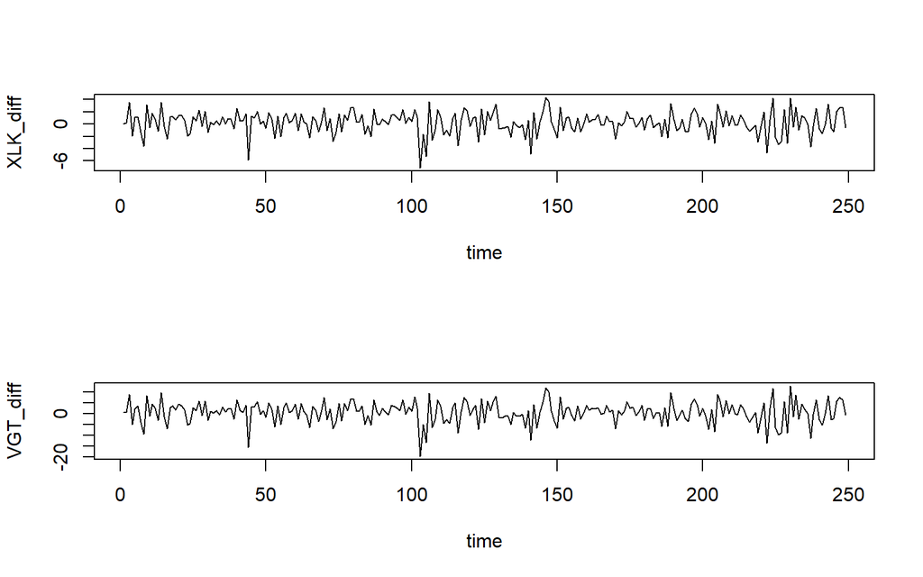

```r
library(MTS)
MTSplot(x_diff)
```

*Fig 13. The First Difference of VGT and XLK over the time*

From the above graph, we notice that two series have similar behaviors. Next, VARorder is used below to compute information criteria and the sequential Chi-square statistics for the VAR process which would help to select the right order of the VAR model.

```r
VARorder(x_diff)
```

```
## selected order: aic =  1
## selected order: bic =  0
## selected order: hq =  0
## Summary table:
##        p     AIC     BIC      HQ    M(p) p-value
##  [1,]  0 -0.0665 -0.0665 -0.0665  0.0000  0.0000
##  [2,]  1 -0.0868 -0.0303 -0.0641 12.1975  0.0159
##  [3,]  2 -0.0694  0.0436 -0.0240  3.3932  0.4943
##  [4,]  3 -0.0482  0.1213  0.0200  2.4895  0.6465
##  [5,]  4 -0.0290  0.1970  0.0620  2.9209  0.5711
##  [6,]  5 -0.0243  0.2582  0.0894  6.1594  0.1876
##  [7,]  6 -0.0580  0.2811  0.0785 14.6405  0.0055
##  [8,]  7 -0.0348  0.3607  0.1244  1.9779  0.7398
##  [9,]  8 -0.0173  0.4347  0.1646  3.2014  0.5247
## [10,]  9  0.0049  0.5134  0.2096  2.1460  0.7089
## [11,] 10  0.0042  0.5692  0.2316  7.0459  0.1335
## [12,] 11  0.0339  0.6554  0.2841  0.5164  0.9719
## [13,] 12  0.0439  0.7220  0.3168  4.6506  0.3251
## [14,] 13  0.0643  0.7989  0.3600  2.4486  0.6539
```

And we fit the VAR model on the two series.

```r
m <- VAR(x_diff)
```

```
## Constant term:
## Estimates:  0.2342681 0.6505823
## Std.Error:  0.1141862 0.3119059
## AR coefficient matrix
## AR( 1 )-matrix
##       [,1] [,2]
## [1,] -1.66 0.56
## [2,] -4.27 1.44
## standard error
##       [,1]  [,2]
## [1,] 0.586 0.215
## [2,] 1.600 0.587
##
## Residuals cov-mtx:
##          [,1]      [,2]
## [1,] 3.147194  8.545747
## [2,] 8.545747 23.482457
##
## det(SSE) =  0.8740583
## AIC =  -0.1024797
## BIC =  -0.0459744
## HQ  =  -0.07973537
```

```r
m$coef
```

```
##            [,1]       [,2]
## [1,]  0.2342681  0.6505823
## [2,] -1.6597601 -4.2655856
## [3,]  0.5598270  1.4378732
```

The above result suggests that only 1 lag is needed for the VAR model which is consistent with the result from VARorder function considering the AIC. And the AR(1) matrix for the VAR model is displayed above. And the following are the 4-step ahead VAR prediction of the first difference of the two assets.

```r
VARpred(m, 4)
```

```
## orig  249
## Forecasts at origin:  249
##      XLK_diff VGT_diff
## [1,]  0.83208   2.1875
## [2,]  0.07786   0.2467
## [3,]  0.24314   0.6732
## [4,]  0.20757   0.5814
## Standard Errors of predictions:
##       [,1]  [,2]
## [1,] 1.774 4.846
## [2,] 1.815 4.946
## [3,] 1.817 4.951
## [4,] 1.817 4.951
## Root mean square errors of predictions:
##       [,1]  [,2]
## [1,] 1.785 4.875
## [2,] 1.909 5.174
## [3,] 1.822 4.962
## [4,] 1.818 4.952
```

## F. Conditional variance analysis: Various types of GARCH models

```r
t.test(XLK_R)
```

```
##
##  One Sample t-test
##
## data:  XLK_R
## t = 1.9162, df = 248, p-value = 0.05649
## alternative hypothesis: true mean is not equal to 0
## 95 percent confidence interval:
##  -5.475153e-05  3.987587e-03
## sample estimates:
##   mean of x
## 0.001966418
```

The above result shows that the p-value is greater than 0.05, thus we fail to reject the null hypothesis and cannot conclude that the mean of the log return of XLK differs from 0. Then we move onto conducting the Box-Ljung test to see if the square of the log return has serial correlation.

```r
Box.test(XLK_R^2,lag=10,type="Ljung")
```

```
##
##  Box-Ljung test
##
## data:  XLK_R^2
## X-squared = 12.217, df = 10, p-value = 0.2708
```

Since the p-value is greater than 0.05, so we cannot conclude that the series have serial correlation so GARCH model does not seem necessary here to model XLK return volatility. However, we conduct a robustness test fitting a GARCH (1, 1) model to see whether the result is consistent with the above test or not.

```r
m1=garchFit(~garch(1,1),data=unclass(XLK_R[-1, ]),trace=F)
summary(m1)
```

```
##
## Title:
##  GARCH Modelling
##
## Call:
##  garchFit(formula = ~garch(1, 1), data = unclass(XLK_R[-1, ]),
##     trace = F)
##
## Mean and Variance Equation:
##  data ~ garch(1, 1)
## <environment: 0x0000000038e5f950>
##  [data = unclass(XLK_R[-1, ])]
##
## Conditional Distribution:
##  norm
##
## Coefficient(s):
##         mu       omega      alpha1       beta1
## 1.7667e-03  5.4348e-05  8.6474e-02  7.0346e-01
##
## Std. Errors:
##  based on Hessian
##
## Error Analysis:
##         Estimate  Std. Error  t value Pr(>|t|)
## mu     1.767e-03   9.774e-04    1.808   0.0707 .
## omega  5.435e-05   3.275e-05    1.660   0.0970 .
## alpha1 8.647e-02   5.221e-02    1.656   0.0976 .
## beta1  7.035e-01   1.459e-01    4.822 1.42e-06 ***
## ---
## Signif. codes:  0 '***' 0.001 '**' 0.01 '*' 0.05 '.' 0.1 ' ' 1
##
## Log Likelihood:
##  676.9158    normalized:  2.718537
##
## Description:
##  Thu Jul 14 01:16:25 2022 by user: Babu
##
##
## Standardised Residuals Tests:
##                                 Statistic p-Value
##  Jarque-Bera Test   R    Chi^2  50.26503  1.216427e-11
##  Shapiro-Wilk Test  R    W      0.9702032 4.494927e-05
##  Ljung-Box Test     R    Q(10)  17.49919  0.06402258
##  Ljung-Box Test     R    Q(15)  22.56158  0.09390224
##  Ljung-Box Test     R    Q(20)  32.25659  0.04063981
##  Ljung-Box Test     R^2  Q(10)  3.426271  0.9695427
##  Ljung-Box Test     R^2  Q(15)  7.992883  0.9240677
##  Ljung-Box Test     R^2  Q(20)  8.635149  0.9867608
##  LM Arch Test       R    TR^2   6.089278  0.9115148
##
## Information Criterion Statistics:
##       AIC       BIC       SIC      HQIC
## -5.404946 -5.348441 -5.405451 -5.382202
```

From the above result, we see that alpha term is not significant which is consistent with our finding from the Ljung Box test that GARCH model is not adequate to model the XLK volatility. In addition, we fitted a GARCH (0,1) model on XLK returns. The results show that while the parameter beta is significant the $R^2$ tells us that the GARCH model is not adequate for predicting volatility.

```r
spec1=ugarchspec(variance.model=list(model="sGARCH",garchOrder=c(0,1)),
                   mean.model=list(armaOrder=c(0,0)))
mm=ugarchfit(spec=spec1,data=XLK_R[-1, ])
mm  ### see output
```

```
##
## *---------------------------------*
## *          GARCH Model Fit        *
## *---------------------------------*
##
## Conditional Variance Dynamics
## -----------------------------------
## GARCH Model  : sGARCH(0,1)
## Mean Model   : ARFIMA(0,0,0)
## Distribution : norm
##
## Optimal Parameters
## ------------------------------------
##        Estimate  Std. Error   t value Pr(>|t|)
## mu     0.001939    0.001021   1.89971 0.057471
## omega  0.000001    0.000002   0.45462 0.649381
## beta1  0.996322    0.001395 714.04945 0.000000
##
## Robust Standard Errors:
##        Estimate  Std. Error   t value Pr(>|t|)
## mu     0.001939    0.000781  2.483410 0.013013
## omega  0.000001    0.000016  0.048074 0.961658
## beta1  0.996322    0.016679 59.735994 0.000000
##
## LogLikelihood : 674.2793
##
## Information Criteria
## ------------------------------------
##
## Akaike       -5.3918
## Bayes        -5.3494
## Shibata      -5.3921
## Hannan-Quinn -5.3747
##
## Weighted Ljung-Box Test on Standardized Residuals
## ------------------------------------
##                         statistic p-value
## Lag[1]                      6.465 0.01100
## Lag[2*(p+q)+(p+q)-1][2]     6.558 0.01563
## Lag[4*(p+q)+(p+q)-1][5]     7.071 0.04985
```

[output cut: 34 more lines]

```
## Negative Sign Bias  1.3522 0.1776
## Positive Sign Bias  0.4489 0.6539
## Joint Effect        2.2332 0.5254
##
##
## Adjusted Pearson Goodness-of-Fit Test:
## ------------------------------------
##   group statistic p-value(g-1)
## 1    20     15.66       0.6799
## 2    30     24.86       0.6857
## 3    40     38.07       0.5122
## 4    50     35.14       0.9320
##
##
## Elapsed time : 0.083776
```

We then tried to switch the i.i.d. distribution from normal to student-t which gives a fatter tails on both ends.

```r
m2=garchFit(~garch(1,1),data=unclass(XLK_R[-1, ]),trace=F, cond.dist="std")
summary(m2)
```

```
##
## Title:
##  GARCH Modelling
##
## Call:
##  garchFit(formula = ~garch(1, 1), data = unclass(XLK_R[-1, ]),
##     cond.dist = "std", trace = F)
##
## Mean and Variance Equation:
##  data ~ garch(1, 1)
## <environment: 0x000000002c2904f8>
##  [data = unclass(XLK_R[-1, ])]
##
## Conditional Distribution:
##  std
##
## Coefficient(s):
##         mu       omega      alpha1       beta1       shape
## 2.8010e-03  2.7354e-05  1.1205e-01  7.8915e-01  6.3039e+00
##
## Std. Errors:
##  based on Hessian
##
## Error Analysis:
##         Estimate  Std. Error  t value Pr(>|t|)
## mu     2.801e-03   9.147e-04    3.062  0.00220 **
## omega  2.735e-05   1.938e-05    1.412  0.15800
## alpha1 1.121e-01   5.714e-02    1.961  0.04986 *
## beta1  7.891e-01   9.617e-02    8.205 2.22e-16 ***
## shape  6.304e+00   2.382e+00    2.647  0.00813 **
## ---
## Signif. codes:  0 '***' 0.001 '**' 0.01 '*' 0.05 '.' 0.1 ' ' 1
##
## Log Likelihood:
##  682.9102    normalized:  2.742611
##
## Description:
##  Thu Jul 14 01:16:25 2022 by user: Babu
##
##
## Standardised Residuals Tests:
##                                 Statistic p-Value
##  Jarque-Bera Test   R    Chi^2  89.3364   0
##  Shapiro-Wilk Test  R    W      0.9604069 2.352e-06
##  Ljung-Box Test     R    Q(10)  16.4405   0.087698
##  Ljung-Box Test     R    Q(15)  21.12911  0.1327547
##  Ljung-Box Test     R    Q(20)  30.34269  0.06448793
##  Ljung-Box Test     R^2  Q(10)  3.148628  0.9777066
##  Ljung-Box Test     R^2  Q(15)  6.32336   0.9737892
##  Ljung-Box Test     R^2  Q(20)  6.979982  0.9967502
##  LM Arch Test       R    TR^2   5.314242  0.9466512
##
## Information Criterion Statistics:
##       AIC       BIC       SIC      HQIC
## -5.445062 -5.374430 -5.445847 -5.416631
```

The results above suggest that alpha and beta are significant under the student-t distribution. And we checked that the Ljung Box tests for $R^2$ are not significant which means that the GARCH model is adequate in predicting XLK return volatility. Below is a graph of fitted volatility from the GARCH model which we could see some sign of volatility clustering.

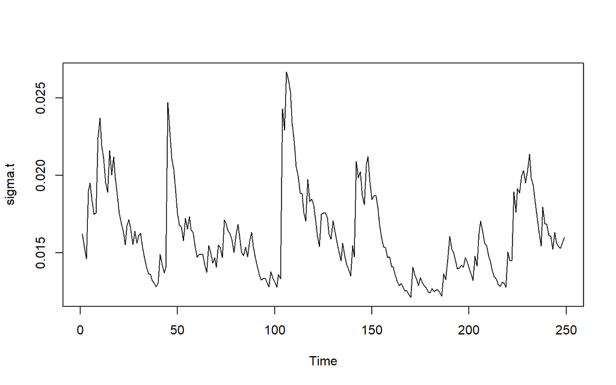

```r
sigma.t=volatility(m2)
ts.plot(sigma.t)
```

We use the above model to forecast the future 50-steps. Since we do not have an ARIMA part in the model, meaning we are treating the return data as i.i.d. (no heteroskedasticity in the mean), we see the mean forecast is constant throughout. The standard deviation column is the forecasting of the GARCH term which would eventually converge to $\sqrt{\frac{\omega}{1-\alpha -\beta}} = \sqrt{\frac{0.00002735}{1-0.1121-0.7891}}==0.01663797$

```r
predict(m2,50)
```

```
##    meanForecast  meanError standardDeviation
## 1   0.002800957 0.01531180        0.01531180
## 2   0.002800957 0.01544803        0.01544803
## 3   0.002800957 0.01556977        0.01556977
## 4   0.002800957 0.01567867        0.01567867
## 5   0.002800957 0.01577617        0.01577617
## 6   0.002800957 0.01586352        0.01586352
## 7   0.002800957 0.01594184        0.01594184
## 8   0.002800957 0.01601208        0.01601208
## 9   0.002800957 0.01607513        0.01607513
## 10  0.002800957 0.01613173        0.01613173
## 11  0.002800957 0.01618257        0.01618257
## 12  0.002800957 0.01622825        0.01622825
## 13  0.002800957 0.01626931        0.01626931
## 14  0.002800957 0.01630622        0.01630622
```

[output cut: 36 more lines]

## G. Value-at-risk analysis

```r
"RMfit" <- function(rtn,estim=TRUE){
# Estimation of the RiskMetrics special IGARCH(1,1) model.
# rtn: return series
#
Idata <<- rtn
Var = var(Idata); S = 1e-6
beta=0.96
if(estim){
params=c(beta = 0.9)
lowerBounds = c(beta= S)
upperBounds = c(beta = 1-S)
# Step 3: set conditional distribution function:
igarchDist = function(z,hh){dnorm(x = z/hh)/hh}
# Step 4: Compose log-likelihood function:
igarchLLH = function(parm){
beta=parm[1]
z = Idata; Meanz=mean(z^2)
e= (1-beta) * c(Meanz, z[-length(Idata)]^2)
h = timeSeries::filter(e,beta, "r", init=Meanz)
#h = filter(e, beta, "r", init=Meanz)
hh = sqrt(abs(h))
llh = -sum(log(igarchDist(z, hh)))
llh
}
###print(igarchLLH(params))
# Step 5: Estimate Parameters and Compute Numerically Hessian:
fit = nlminb(start = params, objective = igarchLLH,
lower = lowerBounds, upper = upperBounds) #, control = list(trace=3))
epsilon = 0.0001 * fit$par
npar=length(params)
Hessian = matrix(0, ncol = npar, nrow = npar)
for (i in 1:npar) {
for (j in 1:npar) {
x1 = x2 = x3 = x4  = fit$par
x1[i] = x1[i] + epsilon[i]; x1[j] = x1[j] + epsilon[j]
x2[i] = x2[i] + epsilon[i]; x2[j] = x2[j] - epsilon[j]
x3[i] = x3[i] - epsilon[i]; x3[j] = x3[j] + epsilon[j]
x4[i] = x4[i] - epsilon[i]; x4[j] = x4[j] - epsilon[j]
Hessian[i, j] = (igarchLLH(x1)-igarchLLH(x2)-igarchLLH(x3)+igarchLLH(x4))/
(4*epsilon[i]*epsilon[j])
}
}
# Step 6: Create and Print Summary Report:
se.coef = sqrt(diag(solve(Hessian)))
tval = fit$par/se.coef
matcoef = cbind(fit$par, se.coef, tval, 2*(1-pnorm(abs(tval))))
dimnames(matcoef) = list(names(tval), c(" Estimate",
" Std. Error", " t value", "Pr(>|t|)"))
cat("\nCoefficient(s):\n")
printCoefmat(matcoef, digits = 6, signif.stars = TRUE)
beta=fit$par[1]
}
else{cat("Default beta = 0.96 is used.","\n")}
###
z=Idata; Mz = mean(z^2)
e= (1-beta)*c(Mz,z[-length(z)]^2)
h = timeSeries::filter(e,beta, "r", init=Mz)
#h = filter(e,beta, "r", init=Mz)
vol = sqrt(abs(h))

# Step 7: compute VaR and ES based on the estimated results
T=length(h)
Sigma=beta*h[T]+(1-beta)*z[T]^2
Vpred=sqrt(Sigma)
tt=matrix(c(T,Vpred),1,2)
colnames(tt) <- c("Orig","Vpred")
cat("\n Volatility prediction:\n")
print(tt)
prob=c(0.95,0.99,0.999)
q1=qnorm(prob)
d1=dnorm(q1); d11=d1/(1-prob)
VaR=q1*Vpred
ES=d11*Vpred
tbl=cbind(prob,VaR,ES)
cat("\n Risk measure based on RiskMetrics:\n")
print(tbl)

RMfit <- list(par=beta,volatility = vol)
}
```

### Risk Metric

```r
#approach 1
require(quantmod)
getSymbols("XLK",from="1998-12-01",to="2022-04-07")
```

```
## [1] "XLK"
```

```r
XLK_Price_Adj=XLK$XLK.Adjusted #% Define a new variable
XLK_R=diff(log(XLK_Price_Adj)) #% Calculate log returns
XLK_R<-na.omit(XLK_R)
XLK_R <- as.numeric(unclass(XLK_R))
#source("RMfit.R")
RMfit(XLK_R)
```

```
##
## Coefficient(s):
##        Estimate  Std. Error  t value   Pr(>|t|)
## beta 0.93255962  0.00454899  205.003 < 2.22e-16 ***
## ---
## Signif. codes:  0 '***' 0.001 '**' 0.01 '*' 0.05 '.' 0.1 ' ' 1
##
##  Volatility prediction:
##      Orig      Vpred
## [1,] 5860 0.01924398
##
##  Risk measure based on RiskMetrics:
##       prob        VaR         ES
## [1,] 0.950 0.03165354 0.03969481
## [2,] 0.990 0.04476820 0.05128934
## [3,] 0.999 0.05946838 0.06479623
```

```r
### One can use default parameter beta = 0.96 wihtout estimation with the command
RMfit(XLK_R,estim=F)
```

```
## Default beta = 0.96 is used.
##
##  Volatility prediction:
##      Orig      Vpred
## [1,] 5860 0.01928147
##
##  Risk measure based on RiskMetrics:
##       prob        VaR         ES
## [1,] 0.950 0.03171520 0.03977214
## [2,] 0.990 0.04485542 0.05138926
## [3,] 0.999 0.05958423 0.06492246
```

Consequently, we have $VaR_{0.95} = 0.03171$, $ES_{0.95} = 0.03977$, $VaR_{0.99} = 0.04485$, $ES_{0.99} = 05138$. These results imply $VaR_{0.95} = \$31,715$ and $ES_{0.95} = \$39,772$ for the next trading day.

```r
"RMeasure" <- function(mu,sigma,cond.dist="norm",df=0){
# calculate VaR and ES for a specified conditional distribution
# p = 0.05, 0.01, 0.001, .0001
#
# cond.dist = "norm", "t", "std"
prob=c(0.95,0.99,0.999,.9999)
if(cond.dist=="norm"){
q1=qnorm(prob)
d1=dnorm(q1)
VaR=mu+q1*sigma
ES=mu+d1*sigma/(1-prob)
tt=cbind(prob,VaR,ES)
}
#
if(cond.dist=="std"){
library(fGarch)
if(df < 2.001)df=2.01
q1=qstd(prob,nu=df)
d1=dstd(q1,nu=df)
VaR=mu+q1*sigma
ES=mu+sigma*(d1/(1-prob))*(((df-2)+q1^2)/(df-1))
tt=cbind(prob,VaR,ES)
}
#
if(cond.dist=="t"){
if(df < 2.01)df=2.01
q1=qt(prob,df)
d1=dt(q1,df)
VaR=mu+q1*sigma
#VaR=mu+q1*sigma/sqrt(df/(df-2))
#ES=mu+sigma/sqrt(df/(df-2))*(d1/(1-prob))*((df+q1^2)/(df-1))
ES=mu+sigma*(d1/(1-prob))*((df+q1^2)/(df-1))
tt=cbind(prob,VaR,ES)
}
cat("\n Risk Measures for selected probabilities: \n")
print(tt)

RMeasure <- list(results=tt)
}
```

```r
### Econometric modeling
require(fGarch)
neg_return = -XLK_R
m1=garchFit(~garch(1,1), data=neg_return, trace=F)
summary(m1)
```

```
##
## Title:
##  GARCH Modelling
##
## Call:
##  garchFit(formula = ~garch(1, 1), data = neg_return, trace = F)
##
## Mean and Variance Equation:
##  data ~ garch(1, 1)
## <environment: 0x000000002dbb0a48>
##  [data = neg_return]
##
## Conditional Distribution:
##  norm
##
## Coefficient(s):
##          mu        omega       alpha1        beta1
## -8.0904e-04   2.6096e-06   1.0718e-01   8.8312e-01
##
## Std. Errors:
##  based on Hessian
##
## Error Analysis:
##          Estimate  Std. Error  t value Pr(>|t|)
## mu     -8.090e-04   1.349e-04   -5.997 2.00e-09 ***
## omega   2.610e-06   3.890e-07    6.708 1.97e-11 ***
## alpha1  1.072e-01   9.020e-03   11.882  < 2e-16 ***
## beta1   8.831e-01   9.159e-03   96.421  < 2e-16 ***
## ---
## Signif. codes:  0 '***' 0.001 '**' 0.01 '*' 0.05 '.' 0.1 ' ' 1
##
## Log Likelihood:
##  17257.63    normalized:  2.944988
##
## Description:
##  Thu Jul 14 01:16:26 2022 by user: Babu
##
##
## Standardised Residuals Tests:
##                                 Statistic p-Value
##  Jarque-Bera Test   R    Chi^2  508.9659  0
##  Shapiro-Wilk Test  R    W      NA        NA
##  Ljung-Box Test     R    Q(10)  17.03966  0.07349104
##  Ljung-Box Test     R    Q(15)  20.81886  0.1427174
##  Ljung-Box Test     R    Q(20)  27.01643  0.1348022
##  Ljung-Box Test     R^2  Q(10)  18.27173  0.05054933
##  Ljung-Box Test     R^2  Q(15)  23.6958   0.07044264
##  Ljung-Box Test     R^2  Q(20)  28.78881  0.09200176
##  LM Arch Test       R    TR^2   19.33845  0.08068138
##
## Information Criterion Statistics:
##       AIC       BIC       SIC      HQIC
## -5.888611 -5.884054 -5.888612 -5.887027
```

```r
pm1=predict(m1,10)
pm1
```

```
##    meanForecast  meanError standardDeviation
## 1  -0.000809042 0.01861885        0.01861885
## 2  -0.000809042 0.01859866        0.01859866
## 3  -0.000809042 0.01857864        0.01857864
## 4  -0.000809042 0.01855879        0.01855879
## 5  -0.000809042 0.01853912        0.01853912
## 6  -0.000809042 0.01851962        0.01851962
## 7  -0.000809042 0.01850029        0.01850029
## 8  -0.000809042 0.01848112        0.01848112
## 9  -0.000809042 0.01846212        0.01846212
## 10 -0.000809042 0.01844328        0.01844328
```

```r
#source("RMeasure.R")
RMeasure(-0.0008, 0.0186) # mean and std
```

```
##
##  Risk Measures for selected probabilities:
##        prob        VaR         ES
## [1,] 0.9500 0.02979428 0.03756646
## [2,] 0.9900 0.04247007 0.04877298
## [3,] 0.9990 0.05667832 0.06182788
## [4,] 0.9999 0.06837371 0.07282772
```

```r
names(pm1)
```

```
## [1] "meanForecast"      "meanError"         "standardDeviation"
```

```r
#0.0008077321   0.01861867  0.01861867
#### 10-day VaR
v1=sqrt(sum(pm1$standardDeviation^2))
RMeasure(-0.0008,v1)
```

```
##
##  Risk Measures for selected probabilities:
##        prob        VaR        ES
## [1,] 0.9500 0.09558419 0.1200697
## [2,] 0.9900 0.13551800 0.1553747
## [3,] 0.9990 0.18027966 0.1965028
## [4,] 0.9999 0.21712480 0.2311567
```

### Quantile regression

```r
#approach 3
getSymbols("XLK",from="1998-12-24",to="2022-04-07")
```

```
## [1] "XLK"
```

```r
XLK_R <- XLK[,6]
XLK_R <- diff(log(XLK_R))
XLK_R <- na.omit(XLK_R)
neg_XLK_R = -XLK_R
quantile(neg_XLK_R,c(0.95,0.99,0.999))
```

```
##        95%        99%      99.9%
## 0.02642759 0.04738742 0.07699919
```

```r
getSymbols("^VIX",from="1998-12-24",to="2022-04-06")
```

```
## [1] "^VIX"
```

```r
VIX <- VIX[,6]
VOL <- (XLK_R)^2
da1 <- cbind(neg_XLK_R, VOL, VIX)
da1 <- na.omit(da1)
colnames(da1)[2]<-"XLK.Volatility"
require(quantreg)
m3=rq(XLK.Adjusted~VIX.Adjusted,data=da1,tau=0.95)
summary(m3)
```

```
##
## Call: rq(formula = XLK.Adjusted ~ VIX.Adjusted, tau = 0.95, data = da1)
##
## tau: [1] 0.95
##
## Coefficients:
##              Value    Std. Error t value  Pr(>|t|)
## (Intercept)  -0.01084  0.00111   -9.75107  0.00000
## VIX.Adjusted  0.00167  0.00007   23.53453  0.00000
```

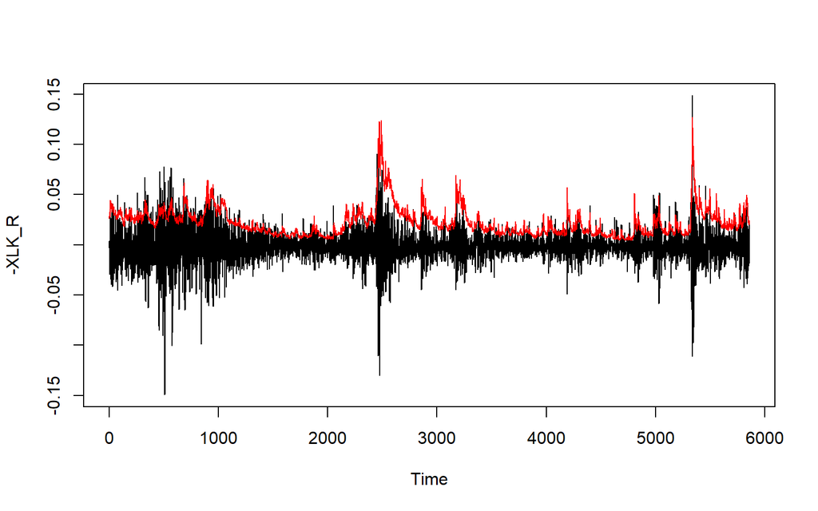

```r
ts.plot(-XLK_R)
lines(m3$fitted.values,col="red")
```

The plot shows the negative XLK log returns and the fitted values of the quantile regression with probability q = 0.95. In red, is the time-varying value-at-risk(VaR) which shows the actual loss may vary when the loss exceeds the VaR.

Consequently, we have for XLK: $VaR_0_._9_5 = 0.026427$, $VaR_0.99 = 0.047387$. These results imply $VaR_0.95 = \$26,427$ and $VaR_0.99 = \$47,387$ for the next trading day.